# Week2 (updated)

### Importing libraries and packages

```python
import numpy as np
import pandas as pd
import re
import pyarabic.araby as araby
import string
import seaborn as sns

import gensim
from gensim.models import Word2Vec

from sklearn.model_selection import train_test_split as split
from sklearn import preprocessing
from imblearn.over_sampling import SMOTE
from imblearn.under_sampling import RandomUnderSampler

from tensorflow.keras import models, layers, preprocessing as kprocessing
from sklearn.linear_model import LogisticRegression
from sklearn.metrics import classification_report, mean_squared_error, confusion_matrix
from sklearn.preprocessing import LabelEncoder as le

import arabic_reshaper
import matplotlib.pyplot as plt
from mpl_toolkits.mplot3d import Axes3D
from bidi.algorithm import get_display
from sklearn import manifold
```

### Importing dataset

```python
#data = pd.read_csv("Data/2019-01_sample.csv") #2019 original
data = pd.read_csv("Data/2020-01_sample.csv") #2020 original
#data = pd.read_csv("Data/clean_data_2019.csv) #2019 cleaned
#data = pd.read_csv("Data/clean_data_2020.csv") #2020 cleaned
```

### Creating Word2Vec embeddings

```python
#the corpus is the column of all the tweets in the dataset
corpus = data["body"]

#splitting the sentences in the corpus into a list of words
word_in_corpus = [] #each cell in this list contains one word from the corpus
for sentence in corpus: word_in_corpus.append(str(sentence).split())

#creating the word2vec embeddings
word2vec = Word2Vec(word_in_corpus, sg = 1, min_count = 1, size = 100, window = 8, iter = 200 )

#testing the similiary of some words in the embedding
word2vec.wv.most_similar("الهلال")
```

```
[('اجواء', 0.7105238437652588),
 ('صدارة', 0.7083373069763184),
 ('https://t.co/NM1ageVLdD', 0.7057105302810669),
 ('https://t.co/q80sfBA1d3', 0.7030788064002991),
 ('بتقزيم', 0.6999222040176392),
 ('#الهلال_99_بطوله', 0.6988992691040039),
 ('كالاجل', 0.6978931427001953),
 ('وطلته.', 0.695364773273468),
 ('هدية', 0.6949037313461304),
 ('وإدارة', 0.6940628886222839)]
```

**in the previous Word2Vec embedding I submitted the cosine similarity score between the words was higher and the words similarity relations made more sense, maybe because the text was cleaned or because the min_count was higher, regardless this embedding performed slightly better**

### Tokenizing, Creating word vocabulary dictionary, Sequencing & Padding

```python
#Tokenizing
tokenizer = kprocessing.text.Tokenizer(lower=True, split=' ', oov_token=None,
                            filters='!"#$%&()*+,-./:;<=>?@[\\]^_`{|}~\t\n')
tokenizer.fit_on_texts(word_in_corpus)

#Creating word vocabulary dictionary
dic_vocabulary = tokenizer.word_index

#sequencing
word_to_seq = tokenizer.texts_to_sequences(word_in_corpus)
```

```python
#padding
padding_seq = kprocessing.sequence.pad_sequences(word_to_seq, maxlen=65, padding="post", truncating="post")
```

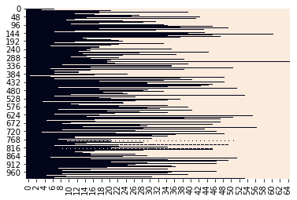

```python
#visualizing sequences to know where to specify padding length (I choose the max len of the padding based on this graph)
sns.heatmap(padding_seq==0, vmin=0, vmax=1, cbar=False)
plt.show()
```

```python
features = padding_seq #the body of the tweet
label = le().fit_transform(data["is_spam"]) #the label of the tweet
```

```python
data["body"][10] #printed a random sentence to test the our text sequences before using them in models
```

```
'#النصر_التعاون  قهررر والله قهررر'
```

```python
#chose a sentence from the original corpus
print("Original Sentence: \n \n", data["body"].iloc[10],"\n \n")

#printed the same chosen sentence but after sequencing, padding, ...
print("Sequences Sentenced: \n \n", features[10], "\n \n")

#choose a word to check its index in the vocbulary matches the value of the word in the sequenced sentence
print("The word قهررر has the index", dic_vocabulary["قهررر"], "in the dictionary")
```

```
Original Sentence:

 #النصر_التعاون  قهررر والله قهررر


Sequences Sentenced:

 [2696 1322   57 1322    0    0    0    0    0    0    0    0    0    0
    0    0    0    0    0    0    0    0    0    0    0    0    0    0
    0    0    0    0    0    0    0    0    0    0    0    0    0    0
    0    0    0    0    0    0    0    0    0    0    0    0    0    0
    0    0    0    0    0    0    0    0    0]


The word قهررر has the index 1322 in the dictionary
```

### Splitting the dataset into training and testing sets

```python
x_train, x_test, y_train, y_test = split(features, label, test_size = 0.3, random_state = 10)
```

### Testing with Logistic Regression

```python
#testing on a logstic regression model - adding another 1500 iterations
LRModel = LogisticRegression(max_iter = 2500)
LRModel.fit(x_train,y_train)
LRprediction = LRModel.predict(x_test)
print(classification_report(y_test, LRprediction))
```

```
              precision    recall  f1-score   support

           0       0.62      0.88      0.73       186
           1       0.39      0.12      0.19       114

    accuracy                           0.59       300
   macro avg       0.51      0.50      0.46       300
weighted avg       0.53      0.59      0.52       300
```

### Creating the NN embeddings

```python
#creating embeddings for the neural network (weights)

#the dictionary contains 13634 words the extra (1) is for the index 0 of unknown words if they occurred instead
#since the embedding is initialized by zeros in the begining with I used pass, it still remained zero,
#but I defined it explicitly this time
embeddings = np.zeros((len(dic_vocabulary)+1, 100))

for word, index in dic_vocabulary.items():
    try:
        embeddings[index] = word2vec.wv[word]
    except:
        embeddings[index] = 0
    break
```

### Creating the NN

```python
#I used an LSTM Neural net with 256 units and a relu activation function
x_input = layers.Input(shape=(65,))

x = layers.Embedding(input_dim = embeddings.shape[0],output_dim = embeddings.shape[1],
                weights = [embeddings],input_length = 65, trainable=True) (x_input)


x = layers.LSTM(256,activation='relu',trainable=True)(x)
x = layers.Dropout(rate=0.5)(x)

y_output = layers.Dense(units=2, activation='softmax')(x)

model = models.Model(inputs=x_input, outputs=y_output)


model.compile(optimizer="adam", loss="sparse_categorical_crossentropy", metrics=["accuracy"])

print(model.summary())

training = model.fit(x_train, y_train, epochs=5, validation_split=0.3, shuffle=True, verbose=0)
```

```
Model: "model"
_________________________________________________________________
Layer (type)                 Output Shape              Param #
=================================================================
input_1 (InputLayer)         [(None, 65)]              0
_________________________________________________________________
embedding (Embedding)        (None, 65, 100)           1363500
_________________________________________________________________
lstm (LSTM)                  (None, 256)               365568
_________________________________________________________________
dropout (Dropout)            (None, 256)               0
_________________________________________________________________
dense (Dense)                (None, 2)                 514
=================================================================
Total params: 1,729,582
Trainable params: 1,729,582
Non-trainable params: 0
_________________________________________________________________
None
```

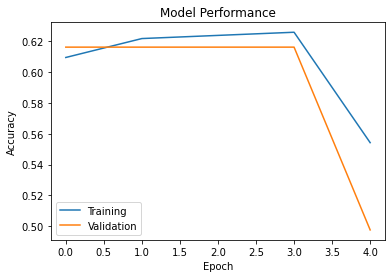

```
              precision    recall  f1-score   support

           0       0.55      0.55      0.55       186
           1       0.27      0.27      0.27       114

    accuracy                           0.45       300
   macro avg       0.41      0.41      0.41       300
weighted avg       0.45      0.45      0.45       300
```

```python
plt.plot(training.history[ 'accuracy' ])
plt.plot(training.history[ 'val_accuracy' ])
plt.title( 'Model Performance' )
plt.ylabel( 'Accuracy' )
plt.xlabel( 'Epoch' )
plt.legend([ 'Training' , 'Validation' ])
plt.show()

#testing the NN model
predicted_prob = model.predict(x_test)
predicted = [y_train[np.argmax(pred)] for pred in predicted_prob]

print(classification_report(y_test, predicted))
```

### Summary

**The things that changed from the past submission:**

1. the word2vec embedding now includes all the words in the corpus not just the words in the training set
2. removed all the dense layers only NN nets and sticked with improving the LSTM NN
3. examined the embeddings contents and checked if the sequences actually represent the same words in the dictionary and made sure each word has its own unique index
4. increased the LSTM units and the number of trainable parameters
5. the unkown words were given the value of 0